# 2 Introduction à R et opérations de base

### 4.0.4 Entrée de données

Afin de procéder au traitement de données, il faut être en mesure d’introduire ces données dans l’environnement R. Plusieurs méthodes existent à cette fin.

#### 4.0.4.1 Entrée manuelle de données: création de vecteurs

Lorsque le nombre de données est petit, on peut les entrer directement dans la console en créant une structure de données, tel qu’un vecteur comme on l’a vu dans les paragraphes précédents. Par exemple, si les notes obtenues par 23 élèves à un examen de mathématiques sont:

0, 1, 2, 12, 12, 14, 18, 21, 21, 23, 24, 25, 28, 29, 30, 30, 30, 33, 36, 44, 45, 47, 50

on pourra définir une variable telle que:

```r
Notes <- c(0, 1, 2, 12, 12, 14, 18, 21, 21, 23, 24, 25,
           28, 29, 30, 30, 30, 33, 36, 44, 45, 47, 50)
Notes
```

```
#>  [1]  0  1  2 12 12 14 18 21 21 23 24 25 28 29 30 30 30 33 36 44 45 47 50
```

Ici, l’opérateur de concaténation, **c()**, est utilisé pour unir l’ensemble des 23 notes dans un vecteur unique auquel on a donné le nom de **Notes**. Pour accéder à une donnée particulière, on utilisera l’indice de cette donnée, ou sa position dans la séquence. Par exemple, la 10e donnée est:

```r
Notes[10]
```

```
#> [1] 23
```

Et les cinq premières données sont:

```r
Notes[1:5]
```

```
#> [1]  0  1  2 12 12
```

Il est possible de modifier une donnée spécifique faisant partie d’un objet. Par exemple:

```r
Notes[10] <- 37
Notes
```

```
#>  [1]  0  1  2 12 12 14 18 21 21 37 24 25 28 29 30 30 30 33 36 44 45 47 50
```

On rencontrera souvent des ensembles de données comprenant plusieurs variables organisées en colonnes, avec plusieurs observations (rangées) pour ces variables.

```r
X <- data.frame(A,B,C,D,E)
X
```

```
#>   A B C D E
#> 1 7 7 9 4 6
#> 2 5 9 6 8 3
#> 3 2 5 9 7 8
#> 4 6 4 7 7 2
#> 5 4 1 2 1 6
#> 6 9 5 7 3 3
#> 7 5 5 3 8 7
```

Par la suite, on peut extraire une ou l’autre des variables en utilisant la syntaxe *dataframe*$*variable*. Par exemple:

```r
X$A
```

```
#> [1] 7 5 2 6 4 9 5
```

```r
X$B
```

```
#> [1] 7 9 5 4 1 5 5
```

```r
X$C
```

```
#> [1] 9 6 9 7 2 7 3
```

```r
X$A[1:2]
```

```
#> [1] 7 5
```

Il est également possible d’opérer sur l’ensemble des éléments que contient le dataframe, ou sur une portion de ce dernier:

```r
X**2
```

```
#>    A  B  C  D  E
#> 1 49 49 81 16 36
#> 2 25 81 36 64  9
#> 3  4 25 81 49 64
#> 4 36 16 49 49  4
#> 5 16  1  4  1 36
#> 6 81 25 49  9  9
#> 7 25 25  9 64 49
```

```r
X$A[1:2] - X$B[3:4]
```

```
#> [1] 2 1
```

Finalement, les fonctions **colnames()** et **rownames()** permettent de modifier le nom des colonnes et des rangées:

```r
colnames(X) <- c("V1", "V2", "V3", "V4", "V5")
rownames(X) <- c("S1", "S2", "S3", "S4", "S5", "S6", "S7")
X
```

```
#>    V1 V2 V3 V4 V5
#> S1  7  7  9  4  6
#> S2  5  9  6  8  3
#> S3  2  5  9  7  8
#> S4  6  4  7  7  2
#> S5  4  1  2  1  6
#> S6  9  5  7  3  3
#> S7  5  5  3  8  7
```

```r
X$V2
```

```
#> [1] 7 9 5 4 1 5 5
```

#### 4.0.4.2 Lecture / Écriture de fichiers de données

Généralement, l’ensemble des données à traiter est trop volumineux pour permettre une simple concaténation et une entrée manuelle. On devra très souvent lire des données qui se trouvent dans des fichiers externes à l’environnement R. On voudra importer des fichiers produits sous Excel, des fichiers textes, ou provenant d’autres logiciels. Pour illustrer la procédure, générons un ensemble de données comprenant 50 observations pour 5 variables (V1-V5), et sauvegardons l’ensemble dans un fichier appelé **data1.txt**:

```r
# Création d'une matrice 50x5, données aléatoires
x <- matrix(rbinom(250,10,0.5),nrow=50, byrow=TRUE)
head(x)
```

```
#>      [,1] [,2] [,3] [,4] [,5]
#> [1,]    5    4    5    6    6
#> [2,]    5    4    3    5    3
#> [3,]    5    4    6    2    2
#> [4,]    4    5    4    9    5
#> [5,]    5    6    5    7    6
#> [6,]    5    9    7    4    4
```

```r
write.table(x,file="data1.txt")
```

La fonction **write.table()** effectue la sauvegarde des données dans le répertoire de travail. Par la suite, ces données peuvent être ré-introduites dans l’environnement de travail à l’aide de la fonction **read.table()**:

```r
y <- read.table(file="data1.txt")
head(y)
```

```
#>   V1 V2 V3 V4 V5
#> 1  5  4  5  6  6
#> 2  5  4  3  5  3
#> 3  5  4  6  2  2
#> 4  4  5  4  9  5
#> 5  5  6  5  7  6
#> 6  5  9  7  4  4
```

Cette commande importera l’ensemble des données contenues dans le fichier data1.txt, dans un dataframe nommé y, en incluant le nom des variables s’il y a lieu.

La fonction ‘**head()**’ permet d’afficher les premières lignes de données, alors que la fonction ‘**tail()**’ en affiche les dernières lignes:

```r
tail(X,n=5)
```

```
#>    V1 V2 V3 V4 V5
#> S3  2  5  9  7  8
#> S4  6  4  7  7  2
#> S5  4  1  2  1  6
#> S6  9  5  7  3  3
#> S7  5  5  3  8  7
```

#### 4.0.4.3 Éditeur de données

Un éditeur de données prenant la forme d’un chiffrier est disponible pour entrer manuellement un ensemble de données. On accède à ce chiffrier en créant un dataframe vide, et en l’ouvrant avec la fonction **fix()**:

```r
NouveauX <- data.frame()
fix(NouveauX)
```

On peut alors modifier le nom des variables (première ligne), et entrer les données comme on le ferait dans Excel, par exemple, tel qu’illustré dans la Figure 4.1.

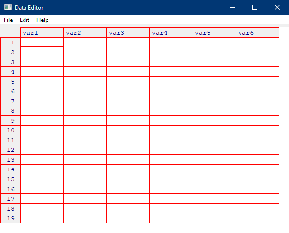

Figure 4.1: Éditeur de données - fix()

De fait, on peut utiliser la fonction **fix()** pour éditer toute variable. Essayez d’éditer la variable X définie plus haut, en lançant la commande:

```r
fix(X)
```

[figure not shown]

Figure 4.2: Éditeur de données

```r
fix(Notes)
```

[figure not shown]

Figure 4.3: Éditeur de données

#### 4.0.4.4 Génération de nombres aléatoires

Finalement, il est souvent approprié de générer des nombres aléatoires. R offre plusieurs fonctions pour ce faire. Une seule sera présentée à ce stade, permettant de générer $n$ données aléatoires comprises entre deux valeurs (minimum et maximum). Ainsi, pour obtenir 20 données comprises entre 1 et 10:

```r
n <- 20
minimum <- 1
maximum <- 10
z <- runif(n,minimum,maximum)
z
```

```
#>  [1] 9.924396 7.641123 2.922724 4.341036 2.775744 8.630061 1.637567 1.920191
#>  [9] 5.192577 4.044175 7.850582 2.521940 3.591573 1.376920 9.944229 7.754300
#> [17] 8.922403 6.930214 3.643293 9.775045
```

ou simplement:

```r
z <- runif(20,1,10)
z
```

```
#>  [1] 7.671237 1.398349 9.587736 3.512942 6.288116 3.493296 6.984082 6.915238
#>  [9] 5.978285 4.144819 1.501223 8.141471 4.581446 5.480905 2.018489 2.057506
#> [17] 7.798681 8.245504 5.585503 2.076799
```

On obtient de nouvelles données à chaque exécution de cette commande.

#### 4.0.4.5 Simulation de données

En exécutant le code suivant, on peut tirer $n$ observations d’une population de forme rectangulaire dont les limites sont choisies au hasard à l’intérieur d’une étendue définie. De cette manière, on ne peut connaître à l’avance les caractéristiques de la population. Donc, d’une population donnée, on tire un échantillon de $n$ observations dont les valeurs sont comprises entre deux valeurs indéterminées, et on obtient quelques indices calculés sur ces observations, de même qu’un graphique. Ce type de génération de données sera très utile dans la suite du cours.

```r
n <- 50  # nombre d'observations à générer
a <- c(10,20)  # étendue de la limite inférieure (population)
b <- c(25,50)  # étendue de la limite supérieure (population)
liminf <- runif(1,a[1],a[2]) # limite inférieure (Pop)
limsup <- runif(1,b[1],b[2]) # limite supérieure (Pop)
x <- runif(n,liminf,limsup)
x
```

```
#>  [1] 16.73254 17.51296 28.41240 32.59691 25.84421 23.39868 32.24073 23.88232
#>  [9] 16.42610 31.06833 27.80498 22.46936 19.90527 25.94692 31.03240 33.61434
#> [17] 31.53831 24.98366 19.98091 17.76968 32.79562 27.70930 19.07452 26.50949
#> [25] 25.28800 19.58502 17.18446 33.10806 19.33640 29.14670 24.13043 17.29418
#> [33] 16.91753 17.39286 25.02382 19.69806 21.34154 27.07481 18.67607 28.79098
#> [41] 28.53670 22.69707 18.11314 23.01963 31.59312 22.04804 29.20043 19.35962
#> [49] 22.70383 27.29182
```

```r
summary(x)
```

```
#>    Min. 1st Qu.  Median    Mean 3rd Qu.    Max.
#>   16.43   19.42   24.01   24.28   28.51   33.61
```

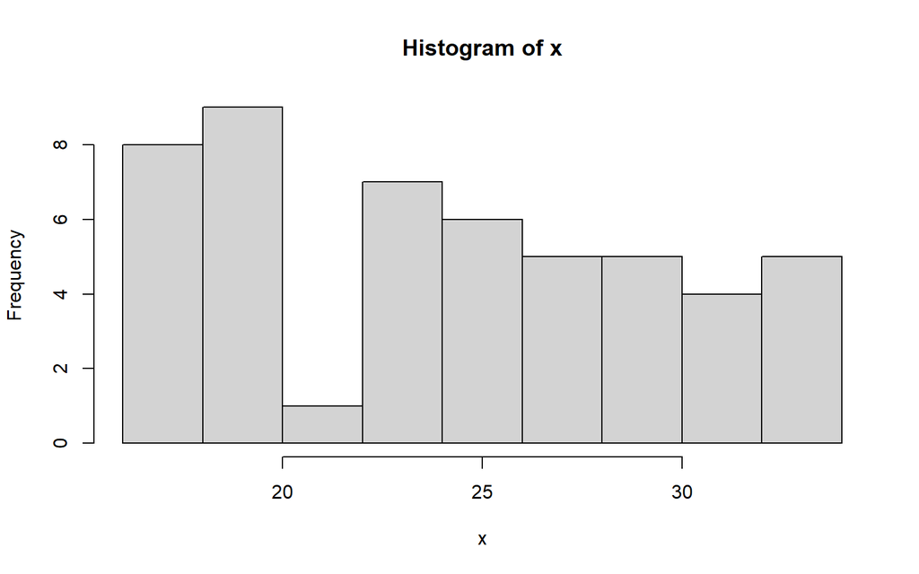

```r
hist(x)
```

Le code suivant poursuit le même objectif, sauf que la distribution de la population est supposée normale, avec une certaine moyenne et un certain écart-type, qui sont sélectionnés au hasard à l’intérieur d’étendues données.Ces paramètres sont donc indéterminés.

```r
n <- 50      # nombre d'observations à générer
moy <- 100   # Moyenne (population)
et <- 15     # Écart-Type (population)
moypop <- runif(1,moy-1.96*et,moy+1.96*et)
etpop <- runif(1,et-et/3,et+et/3)
x <- rnorm(n,moypop,etpop)
x
```

```
#>  [1]  86.57373  70.13529  71.08896  59.00400  76.27524 100.16857  78.84953
#>  [8]  61.12274  65.41176  74.45883  82.84543  47.96903  35.27563  59.08544
#> [15]  96.39246  79.75535 102.73151  49.54368 110.03493  86.81804  72.96143
#> [22] 103.03154  53.34711  77.26514  76.99875  92.70997  59.16576  68.23513
#> [29]  65.74706  81.45257  73.89133  61.42461  83.08705  80.83851  78.61255
#> [36] 103.57672  59.63156  80.80558  58.46821  55.33762  73.26602  79.37860
#> [43]  79.07527  51.48846  91.07655  87.19689  87.31199  94.15296  72.08816
#> [50]  56.40279
```

```r
summary(x)
```

```
#>    Min. 1st Qu.  Median    Mean 3rd Qu.    Max.
#>   35.28   61.20   76.64   75.03   85.70  110.03
```

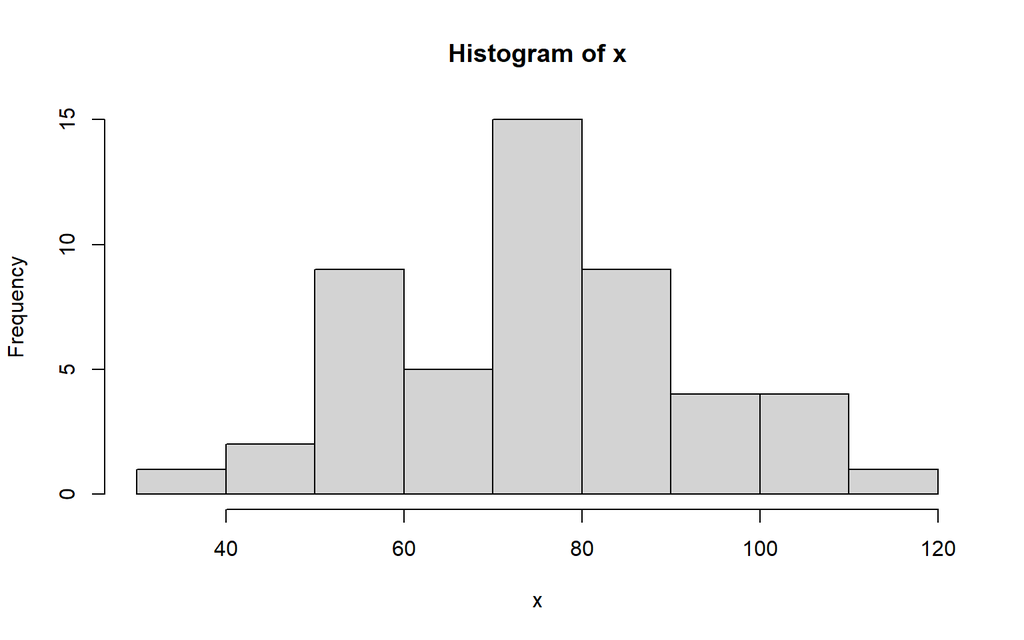

```r
hist(x)
```

Dans les unités suivantes, la génération de tels nombres aléatoires nous sera très utile.

## 4.1 Création de fonctions

Dans les paragraphes précédents, plusieurs fonctions faisant partie de l’environnement R de base ont été présentées. Cet environnement contient une foule de fonctions disponibles sans qu’il soit nécessaire de charger une librairie. On peut obtenir une liste de ces fonctions en lançant la commande:

```r
library(help = "base")
```

S’ajoutent à ces fonctions de base un grand nombre de librairies de fonctions permettant la production de graphiques, par exemple. Sous RStudio, une liste de ces librairies est disponible sous l’onglet **Packages** du panneau **Files/Plots/Packages…**, dans la section libellée **System Library** (voir Figure 4.4).

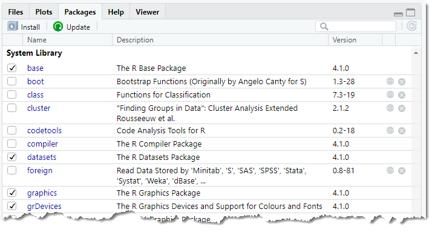

Figure 4.4: Librairies chargées automatiquement sous RStudio

Malgré l’ampleur des fonctions disponibles dans l’environnement R de base, il est souvent utile, ou même nécessaire, de pouvoir définir des fonctions permettant des opérations répétitives. Le processus est simple:

1. Choisir un nom descriptif pour la fonction
2. Définir le ou les arguments que l’on veut soumettre au traitement
3. Écrire le code approprié pour la tâche à exécuter
4. Faire en sorte que le résultat soit accessible au sortir de la fonction.

L’exemple suivant illustre la création d’une fonction et son utilisation. Supposons qu’il vous soit nécessaire de calculer la ou les racines d’une fonction quadratique. Vous vous rappelez que pour une fonction du second degré, telle que $y = ax^2+bx+c$, $y$ est nul pour les valeurs de $x$ données par l’application de l’équation @ref(eq:quadroot).

$$\begin{equation}
x = \frac{-b \pm \sqrt{b^2 - 4ac}}{2a}
(\#eq:quadroot)
\end{equation}$$

Créons une fonction nommée **racquad()**, dont les arguments seront le coefficient quadratique **a**, le coefficient linéaire **b** et la constante **c**. La syntaxe appropriée serait:

```r
racquad = function(a,b,c){
  # Calcul de la quantité sous la racine carrée
  num <- b^2 - 4 * a * c
  # Valeur négative? ==> Nombre complexe
  if(num<0){num = as.complex(num)}
  # Calcul des racines de la fonction et sortie
  r <- (-b+c(1,-1)*sqrt(num))/(2*a)
return(r)
}
```

La fonction **as.complex()** utilisée dans l’énoncé conditionnel **if()** fait de **num** un nombre complexe dans l’éventualité que la quantité sous la racine carrée est négative.

Vérifions notre travail en obtenant les racines de la fonction

$$y = 2.7x^2-6.3x+3.2$$

```r
a <- 2.7
b <- -6.3
c <- 3.2
rac = racquad(a,b,c)
cat("Les racines de cette fonction sont: ",rac)
```

```
#> Les racines de cette fonction sont:  1.586102 0.7472314
```

Quelles sont les racines, si elles existent, de $y = 5.7x^2-8.3x+12.2$:

```r
a <- 5.7
b <- -8.3
c <- 12.2
cat("Les racines de cette fonction sont: ",racquad(a,b,c))
```

```
#> Les racines de cette fonction sont:  0.72807+1.268962i 0.72807-1.268962i
```

Les racines de cette fonction sont des nombres imaginaires.

La définition de fonctions devient vite une activité routinière pour tout analyste utilisant l’environnement R. Prenez note de la syntaxe générale et mettez-la en application dès qu’un ensemble d’opérations à effectuer sur des données est répétitif. Pour plus de détails, l’article suivant pourra vous être utile: [Fonctions en R](https://stt4230.rbind.io/programmation/fonctions_r/)

## 4.2 L’ajout de LIBRAIRIES (‘PACKAGES’)

Une librairie (‘package’) est un ensemble d’objets (données, fonctions) produit par des utilisateurs de R et mis à la disposition de la communauté. Ces librairies sont ajoutées à l’environnement R selon les besoins de l’analyste. Il existe plusieurs milliers de telles librairies, librement disponibles. Il est donc important d’être en mesure de charger une librairie dans notre espace de travail. Sous RStudio, cette tâche devient vite triviale.

### 4.2.1 Librairies provenant de dépôts (CRAN)

Le premier item apparaissant sous l’onglet ‘TOOLS’ du menu principal de RStudio est: ‘**INSTALL PACKAGES…**’ (voir Figure 4.5).

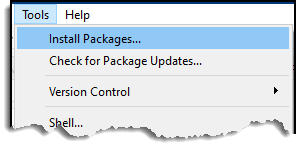

Figure 4.5: RStudio - Menu TOOLS

Cette option produit la fenêtre reproduite dans la Figure 4.6.

[figure not shown]

Figure 4.6: RStudio - ‘INSTALL PACKAGES’

Supposons que l’on ait besoin d’une librairie portant le nom ‘Desctools’, contenant plusieurs fonctions susceptibles d’être utiles pour l’analyse descriptive d’ensembles de données (voir Figure 4.7).

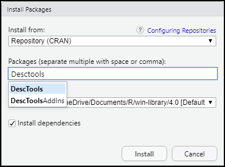

Figure 4.7: Installation de la librairie DescTools

**install.packages(“DescTools”)**

Une librairie demeure en permanence en dormance dans votre système. Lorsque vous en avez besoin, il suffit de la ramener dans l’espace de travail avec la fonction ‘library()’:

```r
library(DescTools)
```

Une fois chargée dans l’espace de travail, l’ensemble des objets contenus dans la librairie devient disponible pour une utilisation immédiate. Par exemple:

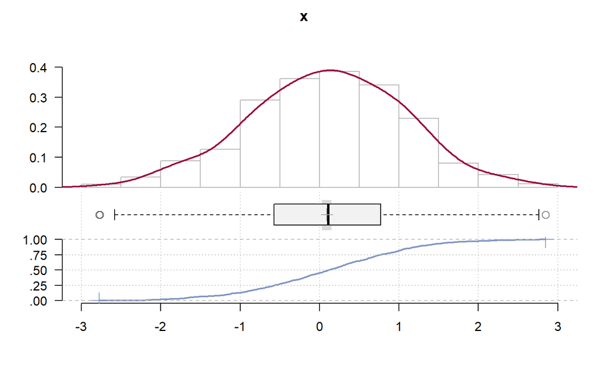

```r
library(DescTools)
x <- rnorm(1000)
PlotFdist(x)
```

Ici, la fonction **PlotFdist()** n’est qu’une des fonctions mises à votre disposition dans la librairie DescTools.

### 4.2.2 Chargement de librairies à partir de GITHUB

Certaines librairies ne sont pas accessibles de la manière décrite ci-dessus, par contre. C’est le cas d’une librairie créée spécifiquement pour ce cours, contenant l’ensemble des fonctions qui seront utilisées pour illustrer les concepts qui seront à l’étude. Pour la charger dans l’environnement de travail, suivez les étapes suivantes:

1. Installez la librairie **devtools**
2. Chargez cette librairie dans votre environnement
3. Installez la librairie **isteahMAT104**, à partir de GitHub
4. Chargez cette librairie dans votre environnement

```r
install.packages("devtools")
library(devtools)
install_github("dco61/isteahMAT104")
library(isteahMAT104)
```

Plusieurs autres librairies sont disponibles de cette manière.

#### 4.2.2.1 Chargement d’une fonction particulière

Lorsque le nom d’une fonction faisant partie d’une librairie est connu, et que l’on a besoin spécifiquement de cette fonction, on peut l’appeler sans avoir à charger la librairie entière. Il suffira d’indiquer le nom de la librairie, suivi de ‘::’, puis du nom de la fonction. Par exemple, créons un vecteur de données sur lequel on applique la fonction PlotFdist() de la librairie DescTools:

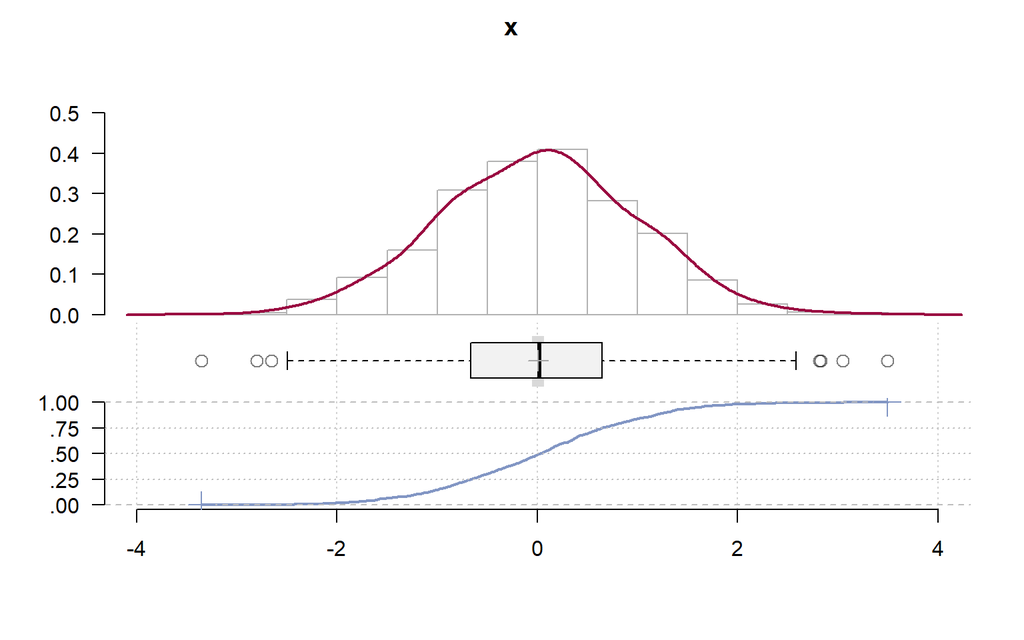

```r
x <- rnorm(1000)
DescTools::PlotFdist(x)
```

De la même manière, l’installation de la librairie **isteahMAT104** est simplifiée:

```r
# devtools::install_github(Nom_de_Compte/Nom_de_librairie)

# Exemple:

devtools::install_github("dco61/isteahMAT104")
```

#### 4.2.2.2 Liste des fonctions contenues dans une librairie

Lorsqu’une librairie est chargée dans votre environnement, vous pouvez obtenir une liste des fonctions qu’elle comporte à l’aide de la fonction **ls()**, ou de la fonction **lsf.str()**, qui ajoute la liste des arguments de chaque fonction. Par exemple:

```r
library(isteahMAT104)
ls("package:isteahMAT104")
```

```
#>  [1] "BlackJack"      "CoinToss"       "consens"        "DispNominal"
#>  [5] "exper"          "HaitiPopGen"    "Mode"           "ModeCat"
#>  [9] "n_classes"      "perm.n.k"       "permute"        "plot_ci"
#> [13] "RandBin"        "RandNorm"       "RandPop"        "RandUnif"
#> [17] "SampDistr"      "SampleAnalysis" "TblFreq"        "TblFreq2"
```

```r
lsf.str("package:isteahMAT104")
```

```
#> BlackJack : function (n = 30)
#> CoinToss : function (n = 1, p = 0.5)
#> consens : function (V, tbl = FALSE)
#> DispNominal : function (x)
#> exper : function (x, nrep = 5000, n = 25, nconf = 0.95)
#> HaitiPopGen : function ()
#> Mode : function (x)
#> ModeCat : function (x)
#> n_classes : function (x)
#> perm.n.k : function (n, k)
#> permute : function (x)
#> plot_ci : function (lo, hi, m)
#> RandBin : function (N = 50, n = 10, p = 0.5)
#> RandNorm : function (n = 50, moy = 100, et = 15)
#> RandPop : function (distr = 2, N = 10000, p1 = 0, p2 = 1)
#> RandUnif : function (n = 50, a = c(10, 20), b = c(25, 50))
#> SampDistr : function (popdata, N_Sample = 1000, n = 25)
#> SampleAnalysis : function (DataIN)
#> TblFreq : function (x, bins = 20)
#> TblFreq2 : function (x, bins = 20)
```

#### 4.2.2.3 Aide concernant une librairie

Vous pouvez obtenir de l’aide concernant une librairie en lançant la commande:

```r
??DescTools
```

La fenêtre d’aide affiche un guide d’utilisation de la librairie.

#### 4.2.2.4 Examiner le code R d’une fonction

Parfois, il est intéressant d’examiner le code R définissant une fonction particulière. On peut visualiser ce code en inscrivant simplement le nom de la fonction (sans argument ni parenthèses) dans la console. Par exemple:

```r
RandNorm
```

```
#> function (n = 50, moy = 100, et = 15)
#> {
#>     sem <- et/sqrt(n)
#>     moypop <- runif(1, moy - 1.96 * sem, moy + 1.96 * sem)
#>     etpop <- runif(1, et - et/3, et + et/3)
#>     x <- rnorm(n, moypop, etpop)
#>     return(x)
#> }
#> <bytecode: 0x0000024aad22cfb0>
#> <environment: namespace:isteahMAT104>
```

#### 4.2.2.5 Charger une librairie à l’intérieur d’une fonction

```r
if (require("DescTools")) install.packages("DescTools")
```

Pour vérifier qu’une librairie (**DescTools** par exemple) est installée, on peut lancer une commande telle que:

```r
"DescTools" %in% rownames(installed.packages())
```

```
#> [1] TRUE
```

On obtiendra **TRUE** si la librairie est présente à l’appel, et **FALSE** dans le cas contraire.

Lorsqu’approprié, on vous informera des librairies que vous devrez charger dans votre système.

### 4.2.3 Chargement de librairies à partir de fichiers .ZIP ou .TAR.GZ

Finalement, il est également possible d’installer une librairie à partir d’un fichier local. Par exemple, le fichier **isteahMAT104_0.5.1.tar.gz** contient localement l’intégralité de la librairie **isteahMAT104**. On peut le télécharger directement de [GITHUB](https://github.com/dco61/isteahMAT104/archive/refs/heads/main.zip), ou du site réservé pour ce cours.

Sous RStudio, il suffira d’utiliser **Tools** - **Install Packages…** - **Install from…** - **Package Archive file (.zip, .tar.gz)**, et naviguer vers le fichier contenant la librairie (Figure 4.8).

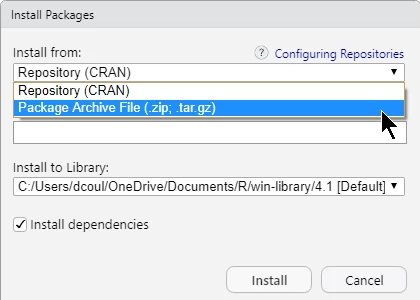

Figure 4.8: Installation d’une librairie à partir d’un fichier local

Finalement, en supposant que le fichier se trouve dans le répertoire de travail (x:), la fonction suivante fera un travail similaire:

```r
install.packages("x:/isteahMAT104.tar.gz",repos=NULL,type="source")
```

Le contenu de cette librairie sera décrit dans les chapitres suivants.

## 4.3 Sauvegarde/Récupération de l’environnement de travail

L’environnement de travail contient l’ensemble des objets (variables, fonctions, structures de données) qui vous sont accessibles dans une session. Il est souvent utile de sauvegarder cet environnement de manière à pouvoir le recharger pour une session ultérieure. Cette opération est rendue possible à partir du menu principal de RStudio (voir Figure 4.9).

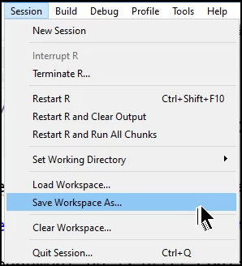

Figure 4.9: Sauvegarde de l’Environnement de travail

On peut également lancer la commande suivante dans la console, avec le même effet:

```r
save.image("fichier_sauvegarde.RData")
```

en remplaçant **fichier_sauvegarde** par le chemin et le nom du fichier dans lequel la sauvegarde doit se faire.

Lorsque nécessaire, on peut récupérer l’environnement de travail en utilisant l’option **Load Workspace…** du menu **Session** (Figure 4.10).

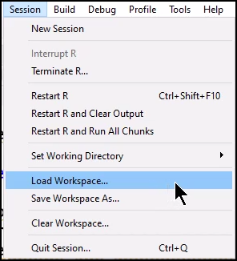

Figure 4.10: Récupération de l’Environnement de travail

et en naviguant jusqu’au fichier préalablement sauvegardé. On peut également obtenir le même résultat en lançant la commande:

```r
load("fichier_sauvegarde.RData")
```

Encore une fois, on remplacera **fichier_sauvegarde** par le chemin et le nom du fichier contenant la sauvegarde à récupérer.

## 4.4 Conclusion

Dans cette section, nous avons abordé les éléments fondamentaux de l’environnement R. Les opérations arithmétiques élémentaires ont été décrites, de même que quelques stratégies d’entrée et d’édition de données. Nous avons introduit RStudio avec lequel nous travaillerons de préférence, en raison de la versatilité que cette interface offre. L’ensemble constitue une boîte à outils qui deviendra rapidement indispensable dans notre étude des probabilités et des statistiques. Les compétences que vous développerez avec ce logiciel vous seront très utiles pour l’ensemble de vos études dans le programme de Sciences de l’ISTEAH. Prenez le temps de revoir ce matériel, manipulez des variables, appliquez les fonctions qui ont été présentées à diverses situations auxquelles vous pourriez penser. Plus vous vous immergerez dans cet ‘univers’, plus vous deviendrez confiant(e)s et efficaces dans vos démarches quantitatives.

## 4.5 Exercice 5

```r
n <- 50  # nombre d'observations à générer
a <- c(10,20)  # étendue de la limite inférieure (population)
b <- c(25,50)  # étendue de la limite supérieure (population)
liminf <- runif(1,a[1],a[2]) # limite inférieure (Pop)
limsup <- runif(1,b[1],b[2]) # limite supérieure (Pop)
x <- runif(n,liminf,limsup)
```

générez un ensemble de 100 données de telle sorte que la plus petite valeur est comprise entre 50 et 65, et la plus grande valeur est comprise entre 100 et 125. (Note: prenez soin d’éditer le code R pour y introduire ces valeurs!).

11. Quelles sont les valeurs minimum et maximum de cet ensemble de données?
12. Combien de données sont supérieures à 90?
13. Combien de données sont inférieures à 80?
14. Tracez un histogramme représentant la distribution de ces données.
15. Une librairie pourrait nous être utile dans les discussions futures: ‘**resample**’. Utilisez **TOOLS > INSTALL PACKAGES…** pour installer cette librairie sur votre ordinateur.
16. Lorsque l’installation de la librairie sera complétée, chargez-la dans votre espace de travail:

```r
library(resample)
```

et exécutez la commande suivante pour en vérifier le bon fonctionnement:

```r
bootC <- bootstrap(x, mean, seed = 0)
print(bootC)
```

```
#> Call:
#> bootstrap(data = x, statistic = mean, seed = 0)
#> Replications: 10000
#>
#> Summary Statistics:
#>         Observed         SE        Mean         Bias
#> mean 0.007276678 0.03065568 0.007527698 0.0002510205
```

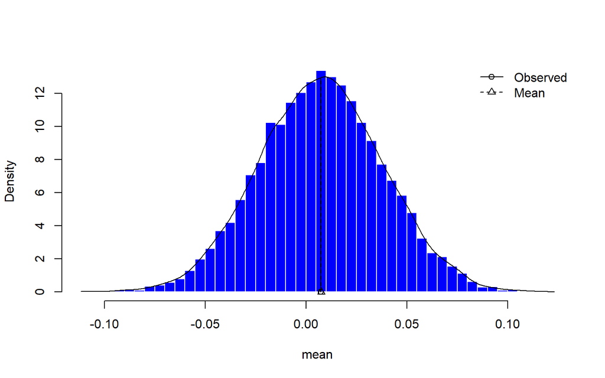

```r
hist(bootC)
```

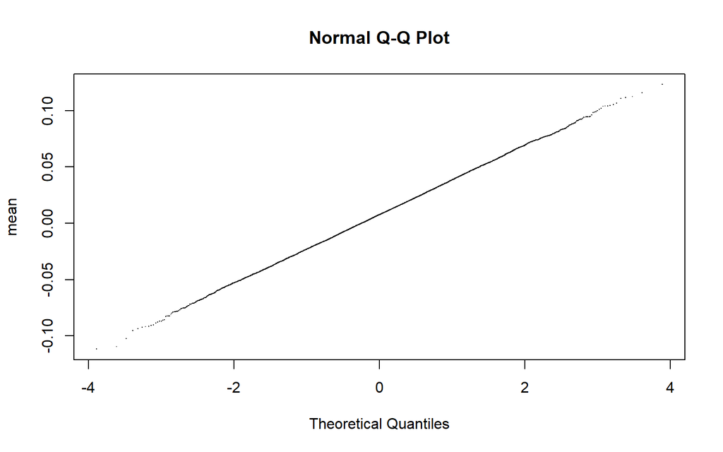

```r
qqnorm(bootC)
```

```r
quantile(bootC, probs = c(.25, .975))
```

```
#>              25%      97.5%
#> mean -0.01346051 0.06809802
```

```r
CI.percentile(bootC)
```

```
#>             2.5%      97.5%
#> mean -0.05205575 0.06810599
```

Si des graphiques et des items étiquettés **Summary Statistics** apparaissent, l’installation s’est déroulée correctement, et de nouvelles fonctions ont été ajoutées à votre système.

## 4.6 Solutionnaire

### 4.6.1 Exercice 1

> 1. Au marché, vous achetez pour 200 gourdes de pommes de terre, pour 327 gourdes de raisins, pour 178 gourdes d’ananas et pour 1238 gourdes de poisson. Utilisez la console R pour calculer le coût total de vos achats.

```r
200+327+178+1238
```

```
#> [1] 1943
```

> 2. Arrivé à la caisse, vous vous rendez compte qu’un des ananas est gâté et vous décidez de le retirer de votre achat, ce qui réduit le coût de 53 gourdes. Utilisez R pour calculer la somme qu’il vous reste à payer.

```r
200+327+178+1238 - 53
```

```
#> [1] 1890
```

> 3. Pour que tout soit bien clair dans la transaction que vous effectuez au marché, lancez les commandes suivantes dans la console:

```r
pomme.de.terre <- 200
raisins <- 327
ananas <- 178 - 53
poisson <- 1238

a <- 'Le montant total à payer ce matin est: '
montant <- pomme.de.terre + raisins + ananas + poisson
cat(a,montant,' gourdes')
```

```
#> Le montant total à payer ce matin est:  1890  gourdes
```

> 4. Les prix de certaines denrées ont changé depuis votre dernière visite au marché. Pour les pommes de terre, il y a une augmentation de 20%, et pour le poisson, une réduction de 38 gourdes. Vous voulez acheter les mêmes denrées que la dernière fois. Obtenez le montant de votre facture,,,

```r
pomme.de.terre <- 200*1.2 # 20% d'augmentation
raisins <- 327
ananas <- 178 - 53
poisson <- 1238 - 38

a <- 'Le montant total à payer ce matin est: '
montant <- pomme.de.terre + raisins + ananas + poisson
cat(a,montant,' gourdes')
```

```
#> Le montant total à payer ce matin est:  1892  gourdes
```

### 4.6.2 Exercice 2

> 1. La largeur d’un rectangle mesure 4 centimètres, et sa hauteur mesure 18 centimètres. Quelle est la périphérie de ce rectangle?

```r
# La périphérie d'un rectangle est 2 fois sa largeur + sa hauteur
2*(4 + 18)
```

```
#> [1] 44
```

> 2. Quelle est la surface du rectangle décrit en (1)?

```r
# La surface d'un rectangle est sa largeur x sa hauteur
4*18
```

```
#> [1] 72
```

> 3. Dans un mètre, il y a 39.37008 pouces. Combien y’a-t’il de pouces dans 2.5 mètres?

```r
2.5 * 39.37008
```

```
#> [1] 98.4252
```

> 4. Le volume d’une sphère est égal à $(4\pi r^2)/3$. Quel serait le volume d’une sphère dont le **diamètre** serait égal à 8.92745?

```r
# Le rayon est la moitié du diamètre. Donc...
rayon <- 8.92745/2
cat("Le volume de la sphère = ",(4*pi*rayon^2)/3)
```

```
#> Le volume de la sphère =  83.46098
```

> 5. Si x = 4.5327 et y = 8.4893, quelle est la valeur de l’expression:

$$\sqrt{(x^3+y^4)}-(x/2+x\cdot y/5)^3$$

```r
x <- 4.5327
y <- 8.4893
sqrt(x^3+y^4)-(x/2+x*y/5)^3
```

```
#> [1] -916.0033
```

### 4.6.3 Exercice 3

> 1. Obtenez la liste des variables qui ont été créées dans votre espace de travail: fonction ls()

```r
ls()
```

```
#>  [1] "a"              "A"              "A_bcd"          "a1"
#>  [5] "A1.B2_c3"       "a2"             "a3"             "a4"
#>  [9] "abcd"           "Abcd"           "ananas"         "b"
#> [13] "B"              "bootC"          "c"              "C"
#> [17] "D"              "E"              "et"             "etpop"
#> [21] "liminf"         "limsup"         "maximum"        "minimum"
#> [25] "montant"        "moy"            "moypop"         "n"
#> [29] "Notes"          "poisson"        "pomme.de.terre" "rac"
#> [33] "racquad"        "raisins"        "rayon"          "u"
#> [37] "w"              "x"              "X"              "y"
#> [41] "z"
```

> 2. Nous n’avons plus besoin de ces variables. Effacez 3 des variables qui se trouvent dans votre espace de travail: fonction rm()

```r
rm(rayon,x,y)
```

> 3. Pour vous faciliter la tâche, effacez toutes les variables en utilisant rm(list=ls()).

```r
rm(list=ls())
```

> 4. Il y a 6.28981077 $m^3$ de pétrole dans un baril. Définissez une variable contenant ce facteur de conversion.

```r
baril.m3 <- 6.28981077
```

> 5. Un baril de pétrole vaut $60. Vous avez besoin de 25 $m^3$ de pétrole pour vos opérations hebdomadaires. Quel sera le montant de votre facture de pétrole?

```r
cat("Facture hebdomadaire = ", 25/baril.m3*60)
```

```
#> Facture hebdomadaire =  238.4809
```

### 4.6.4 Exercice 4

```r
x <- runif(20,1,10)
y <- runif(20,1,10)
```

> 2. Dans la variable x, quelles sont les valeurs supérieures à 15?

```r
cat("Les indices des valeurs de x > 15 sont: ", which(x >
    15), "\n")
```

```
#> Les indices des valeurs de x > 15 sont:
```

```r
cat("Leurs valeurs sont: ", x[which(x > 15)])
```

```
#> Leurs valeurs sont:
```

> 3. Dans la variable x, quelle est la somme des valeurs supérieures à 5?

```r
cat("La somme de ces valeurs est : ",sum(x[which(x>5)]))
```

```
#> La somme de ces valeurs est :  114.428
```

> 4. Quelle est la valeur de $\sum_{i = 1}^{20}{x_i^2}$ ?

```r
cat("La somme des carrés de x = ",sum(x^2))
```

```
#> La somme des carrés de x =  964.7127
```

> 5. Définissez un vecteur nommé $y$ contenant la séquence des valeurs de 1 à 20.

```r
y <- 1:20
```

> 6. Calculez la somme de x et du vecteur que vous venez de définir.

```r
x + y
```

```
#>  [1]  5.618290 11.657064  9.191454  7.940329 14.044251 11.193130 15.363781
#>  [8] 14.810582 12.788250 18.438497 18.725053 21.088400 18.279364 16.917315
#> [15] 23.930024 22.602192 24.500722 19.979182 25.880494 28.722990
```

> 7. Déterminez l’étendue de la variable x.

```r
range(x)
```

```
#> [1] 1.979182 9.657064
```

> 8. Calculez la somme des produits xy.

```r
sum(x*y)
```

```
#> [1] 1377.581
```

> 9. Déterminez le vecteur des valeurs les plus élevées de x et de y.

```r
pmax(x, y)
```

```
#>  [1]  4.618290  9.657064  6.191454  4.000000  9.044251  6.000000  8.363781
#>  [8]  8.000000  9.000000 10.000000 11.000000 12.000000 13.000000 14.000000
#> [15] 15.000000 16.000000 17.000000 18.000000 19.000000 20.000000
```

> 10. Déterminez le vecteur des valeurs les plus petites de x et de y.

```r
pmin(x, y)
```

```
#>  [1] 1.000000 2.000000 3.000000 3.940329 5.000000 5.193130 7.000000 6.810582
#>  [9] 3.788250 8.438497 7.725053 9.088400 5.279364 2.917315 8.930024 6.602192
#> [17] 7.500722 1.979182 6.880494 8.722990
```